# Exploratory Data Analysis

2022-09-19

## Installation

```r
library(gaitR)
```

# An Initial Analysis of the Gait Profiles

## Extracting the Gait Profiles Data

```r
gp <- extract_gait_profiles()

# number of unique subjects
unique(gp$subject_num)
```

```
##  [1] "01" "02" "03" "04" "05" "06" "07" "08" "09" "10" "11" "12" "14"
## [14] "15"
```

## Exploratory Data Analysis

### Plots of Select Gait Profile Samples

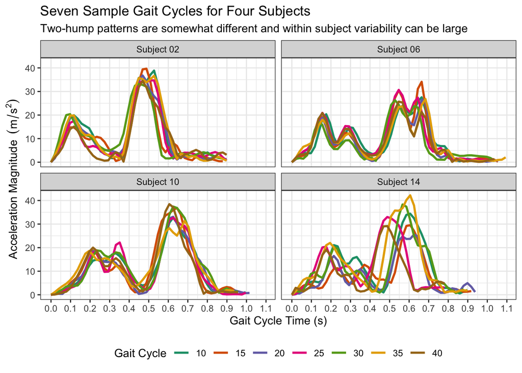

```r
sample_subjects <- c('02', '06', '10', '14')
cycle_id <- c('10', '15', '20', '25', '30', '35', '40')
plot_profile_samples(gp, sample_subjects, cycle_id)
```

### An Animated Plot of Subject 01’s Gait Cycles

```
## nframes and fps adjusted to match transition
```

[output not shown]

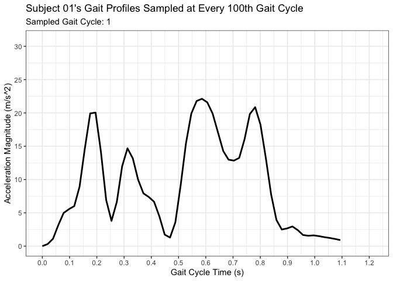

```r
plot_animated(gp, subject_id='01')
```

# Insights Gained from the First Quick Analysis

- There is a large variability in the gait profiles within participants.
- Despite the above observation, the general shapes of the profiles across participants can be different.
- We can potentially capitalize on insights from **facial recognition**. Specifically, the face recognition literature divides problems into:
  - *Facial Detection:* For example, using [Google’s ML Kit’s face detection API](https://developers.google.com/ml-kit/vision/face-detection) ML practitioners can “detect faces in an image, identify key facial features, and get the contours of detected faces. Note that the API detects faces, it does not recognize people.”
  - *Facial Recognition:* where the goal is to identify who the person in the picture is.
- The analogy for us would be that we would like to potentially **detect** (segment/extract) pure walking tasks from a long stream of accelerometer/IMU data, and then design/test methodologies that are best suited for **gait recognition** (whose gait is this)? Due to the somewhat large variability within participants, we will need to examine this question in a potentially repeated manner (using moving windows of different sizes) so that we can determine what is the smallest chunk of data that can be used to recognize a person based on their gait? **Complicating factors:**
  - Fatigue; people walk differently when they are fatigued.
  - The type of task (e.g., walking while pushing a cart, or walking while carrying an object) may change the gait profile.
  - The preprocessing performed on the sensor data (e.g., cutoffs used for filtering/smoothing the raw sensor data may play a role).
  - Etc.
- Once we show that a person’s gait can be considered like a bio-metric feature (which we will also need to see the authentication literature for support). The question would be how do we share a person’s data without sharing their unique `fingerprint`. The spectrum of methodologies here are very wide. **Possible approaches:**
  - Add noise to the profiles??
  - Sharing just features extracted from a given person??
  - Performing a cluster analysis and only share percentiles of the cluster data that are extrapolated (i.e., would grantee that they do not belong to an individual)??
  - Etc.